# Multiple Linear Regression

Arnab Aich

## Introduction

Multiple Linear Regression (MLR) extends Simple Linear Regression to include multiple predictor (independent) variables. The goal is to model the relationship between a dependent variable $y$ and multiple independent variables $x_1, x_2, ..., x_p$. The model assumes a linear relationship between the variables.

We will use `mtcars` Dataset for our analysis. The `mtcars` dataset contains various characteristics of car models, including miles per gallon (`mpg`), horsepower (`hp`), weight (`wt`), gear type (`gear`), cylinder (`cyl`), displacement (`disp`), drag time (`qsec`), carburetors (`carb`), transmission (`am`). We will use all variables in the `mtcars` dataset to predict `mpg`.

|  | mpg | cyl | disp | hp | drat | wt | qsec | vs | am | gear | carb |
| --- | --- | --- | --- | --- | --- | --- | --- | --- | --- | --- | --- |
| Mazda RX4 | 21.0 | 6 | 160 | 110 | 3.90 | 2.620 | 16.46 | 0 | 1 | 4 | 4 |
| Mazda RX4 Wag | 21.0 | 6 | 160 | 110 | 3.90 | 2.875 | 17.02 | 0 | 1 | 4 | 4 |
| Datsun 710 | 22.8 | 4 | 108 | 93 | 3.85 | 2.320 | 18.61 | 1 | 1 | 4 | 1 |
| Hornet 4 Drive | 21.4 | 6 | 258 | 110 | 3.08 | 3.215 | 19.44 | 1 | 0 | 3 | 1 |
| Hornet Sportabout | 18.7 | 8 | 360 | 175 | 3.15 | 3.440 | 17.02 | 0 | 0 | 3 | 2 |
| Valiant | 18.1 | 6 | 225 | 105 | 2.76 | 3.460 | 20.22 | 1 | 0 | 3 | 1 |

## Multiple Linear Regression Analysis

Multiple Linear Regression analysis involves several steps, including model fitting, coefficient estimation, ANOVA table, residuals analysis, and $R^2$ calculation.

### Correlation Matrix

The table below shows the correlation matrix for all variables in the `mtcars` dataset:

|  | mpg | cyl | disp | hp | drat | wt | qsec | vs | am | gear | carb |
| --- | --- | --- | --- | --- | --- | --- | --- | --- | --- | --- | --- |
| mpg | 1.00 | -0.85 | -0.85 | -0.78 | 0.68 | -0.87 | 0.42 | 0.66 | 0.60 | 0.48 | -0.55 |
| cyl | -0.85 | 1.00 | 0.90 | 0.83 | -0.70 | 0.78 | -0.59 | -0.81 | -0.52 | -0.49 | 0.53 |
| disp | -0.85 | 0.90 | 1.00 | 0.79 | -0.71 | 0.89 | -0.43 | -0.71 | -0.59 | -0.56 | 0.39 |
| hp | -0.78 | 0.83 | 0.79 | 1.00 | -0.45 | 0.66 | -0.71 | -0.72 | -0.24 | -0.13 | 0.75 |
| drat | 0.68 | -0.70 | -0.71 | -0.45 | 1.00 | -0.71 | 0.09 | 0.44 | 0.71 | 0.70 | -0.09 |
| wt | -0.87 | 0.78 | 0.89 | 0.66 | -0.71 | 1.00 | -0.17 | -0.55 | -0.69 | -0.58 | 0.43 |
| qsec | 0.42 | -0.59 | -0.43 | -0.71 | 0.09 | -0.17 | 1.00 | 0.74 | -0.23 | -0.21 | -0.66 |
| vs | 0.66 | -0.81 | -0.71 | -0.72 | 0.44 | -0.55 | 0.74 | 1.00 | 0.17 | 0.21 | -0.57 |
| am | 0.60 | -0.52 | -0.59 | -0.24 | 0.71 | -0.69 | -0.23 | 0.17 | 1.00 | 0.79 | 0.06 |
| gear | 0.48 | -0.49 | -0.56 | -0.13 | 0.70 | -0.58 | -0.21 | 0.21 | 0.79 | 1.00 | 0.27 |
| carb | -0.55 | 0.53 | 0.39 | 0.75 | -0.09 | 0.43 | -0.66 | -0.57 | 0.06 | 0.27 | 1.00 |

The correlation matrix helps identify relationships between variables. Strong correlations (positive or negative) indicate potential **multicollinearity**, which can affect the model’s performance.

### Mathematical Model

The equation for Multiple Linear Regression is:

$$y = \beta_0 + \beta_1 x_1 + \beta_2 x_2 + ... + \beta_p x_p + \epsilon$$

where:

- $y$ is the dependent variable.
- $\beta_0$ is the intercept.
- $\beta_1, \beta_2, ..., \beta_p$ are the coefficients for each independent variable $x_1, x_2, ..., x_p$. One unit change in $x_j$corresponds to a $\beta_j$ change in $y$ when all other variables are held constant($j = 1(1)p$).
- $\epsilon$ represents the error term.

The coefficients $\beta_0, \beta_1, \beta_2, ..., \beta_p$ are estimated using the method of least squares to minimize the sum of squared residuals.

### Coefficient Estimation

In Multiple Linear Regression (MLR), the goal is to estimate the coefficients (parameters) $\beta_0, \beta_1, ..., \beta_n$ that define the relationship between the dependent variable $y$ and the independent variables $x_1, x_2, ..., x_n$. These coefficients are estimated using the **Ordinary Least Squares (OLS)** method, which minimizes the sum of squared differences between the observed values and the predicted values. The least squares criterion is expressed as:

$$\text{SSE} = \sum_{i=1}^{n} (y_i - \hat{y}_i)^2 = \sum_{i=1}^{n} (y_i -
\beta_0 - \beta_1 x_{1i} - \beta_2 x_{2i} - ... - \beta_p x_{pi})^2$$

The objective is to find the values of $\beta_0, \beta_1, ..., \beta_n$ that minimize the SSE. This is achieved using the following matrix notation: The MLR model can be written in matrix form as:

$$\mathbf{Y} = \mathbf{X} \boldsymbol{\beta} + \boldsymbol{\epsilon}$$

where:

- $\mathbf{Y}$ is an $n \times 1$ vector of observed values,
- $\mathbf{X}$ is an $n \times (p+1)$ matrix (including a column of 1s for the intercept and $p$ independent variables),
- $\boldsymbol{\beta}$ is a $(p+1) \times 1$ vector of coefficients,
- $\boldsymbol{\epsilon}$ is an $n \times 1$ vector of error terms.

The coefficients $\boldsymbol{\beta}$ can be estimated using the following formula:

$$\hat{\boldsymbol{\beta}} = (\mathbf{X}^T \mathbf{X})^{-1} \mathbf{X}^T
\mathbf{Y}$$

where:

- $\mathbf{X}^T$ is the transpose of matrix $\mathbf{X}$,
- $(\mathbf{X}^T \mathbf{X})^{-1}$ is the inverse of $\mathbf{X}^T \mathbf{X}$,
- $\hat{\boldsymbol{\beta}}$ represents the vector of estimated coefficients $(\hat{\beta_0}, \hat{\beta_1}, ..., \hat{\beta_n})$.

### Linear Regression Inference

This section covers the statistical inference aspects of Linear Regression, including coefficient estimation, hypothesis testing, and model evaluation. This section is also applicable to **Simple Linear Regression**.

#### Hypothesis Related to MLR

Here are the hypotheses commonly tested in Multiple Linear Regression:

1. **Overall Model Significance (Global F-Test)**
   - **Null Hypothesis ($H_0$)**: $\beta_1 = \beta_2 = ... = \beta_p = 0$ (None of the independent variables have a significant effect on the dependent variable.)
   - **Alternative Hypothesis ($H_a$)**: At least one $\beta_j \neq 0$ (At least one independent variable significantly affects the dependent variable.)
2. **Individual Coefficient Significance (t-Test for Each Coefficient)**
   - **Null Hypothesis ($H_{0j}$)**: $\beta_j = 0$ (The predictor $x_j$ has no effect on the dependent variable $y$.)
   - **Alternative Hypothesis ($H_{aj}$)**: $\beta_j \neq 0$ (The predictor $x_j$ has a significant effect on the dependent variable $y$.)

#### Testing Overall Model Significance (Global F-Test)

The **Residual Standard Error** or **Mean Squared Error** measures the typical distance between the observed data points and the regression line. It is calculated using the formula:
$$\text{MSE} = \frac{\text{SSE}}{n - p - 1}$$
where:

**SSE**: The Sum of Squared Errors (Residuals), $\sum (y_i - \hat{y}_i)^2$,

- **$n$**: Total number of observations,
- **$p$**: Number of independent variables (predictors) in the model.

The **degrees of freedom** for the Residual Standard Error is given by $n - p - 1$.

**SSR** :The Sum Square Regression measures the variability explained by the model. It is calculated as: $\sum_{i=1}^n (\hat{y}_i - \bar{y})^2$ , where:

- $\hat{y}_i$ is the predicted value of the dependent variable $y$,
- $\bar{y}$ is the mean of the dependent variable $y$.

The **degrees of freedom** for the Sum Square Regression is given by $p$. Thus the mean square regression is calculated as:
$$MSR =
\frac{SSR}{p}$$

The F Statistic is calculated as:
$$F_{stat} = \frac{SSR/p}{SSE/(n-p-1)} = \frac{MSR}{MSE}$$
Under the Null Hypothesis
$$F_{stat}\sim
F_{p,n-p-1}$$
A significant F-statistic indicates that the model is useful in explaining the variability in the dependent variable.

The p-value associated with the F-statistic is used to determine the significance of the model which is calculated as:

$$\text{P-value} = P_{H_0}(F_{p, n-p-1}
> F_{obs})$$

where $F_{obs}$ is the observed value of test statistics. The anova table below summarizes the results of the F-test:

| Source | SS | df | MS | F.stat | Crit.Value | p.value |
| --- | --- | --- | --- | --- | --- | --- |
| Regression | 978.55 | 10 | 97.86 | 13.93 | 2.32 | 3.79e-07 |
| Error | 147.49 | 21 | 7.02 |  |  |  |
| Total | 1126.05 | 31 |  |  |  |  |

Based on the Anova Table above, the F-statistic is 13.93 with a p-value of 3.79e-07. Since the p-value is less than 0.05, we reject the null hypothesis and conclude that the model is significant.

#### Testing for Individual coefficients (individual t-Test)

The t-statistic is used to test the significance of individual coefficients.

The std error of the coefficients are calculated as:
$$\text{SE}(\hat{\beta}_j) =
\sqrt{\text{Var}(\hat{\beta}_j)} =
\sqrt{\frac{\text{MSE}}{\sum_{i=1}^{n}(x_{ij} -
\bar{x}_j)^2}}$$

The t-statistic for testing the significance of the $j$th coefficients is calculated as:
$$t_j^{stat} =
\frac{\hat{\beta}_j}{\text{SE}(\hat{\beta}_j)}$$

where $\hat{\beta}_j$ are the least square estimates of $\beta_j$. Under the Null Hypothesis $H_{0j}$:
$$t_j^{stat} \sim t_{n-p-1}$$
A significant t-statistic indicates that the coefficient is significantly different from zero.

where $t_j^{obs}$ is the observed value of test statistic.For the `mtcars` dataset, the estimated coefficients and other relevant statistics are as follows:

| Variable | Estimate | Std. Error | t value | Pr(>\|t\|) |
| --- | --- | --- | --- | --- |
| (Intercept) | 12.303 | 18.718 | 0.657 | 0.518 |
| cyl | -0.111 | 1.045 | -0.107 | 0.916 |
| disp | 0.013 | 0.018 | 0.747 | 0.463 |
| hp | -0.021 | 0.022 | -0.987 | 0.335 |
| drat | 0.787 | 1.635 | 0.481 | 0.635 |
| wt | -3.715 | 1.894 | -1.961 | 0.063 |
| qsec | 0.821 | 0.731 | 1.123 | 0.274 |
| vs | 0.318 | 2.105 | 0.151 | 0.881 |
| am | 2.520 | 2.057 | 1.225 | 0.234 |
| gear | 0.655 | 1.493 | 0.439 | 0.665 |
| carb | -0.199 | 0.829 | -0.241 | 0.812 |

The table above shows the estimated coefficients, standard errors, t-statistics, and p-values for each predictor variable. The p-values help determine the significance of each predictor in the model.

### Some Important Diagnostic Tools

Here are some key diagnostic tools to evaluate the performance of the Multiple Linear Regression model:

#### Residual Analysis

The fitted(preditction) values are calculated as:
$$\hat{y} = \boldsymbol{X\hat{\beta}}
=\hat{\beta}_0 + \hat{\beta}_1 x_1 + \hat{\beta}_2 x_2 + ... +
\hat{\beta} x_p$$

where:

- $\hat{y}$ is the predicted value of the dependent variable $y$.
- $\hat{\beta}_0, \hat{\beta}_1, ..., \hat{\beta}_n$ are the estimated coefficients.
- $x_1, x_2, ..., x_n\equiv \boldsymbol{X}$ are the independent variables.

For example, to predict `mpg` for: - `hp = 110`, `wt = 2.875`, `qsec = 18`,`drag = 3.9`, `cyl = 4`, `disp = 140`, `vs = 1`, `am = 1`, `gear = 4`, `carb = 2` the predicted mpg is calculated as:

Using the estimates from the coefficients table the predicted mpg is 23.59.

In Multiple Linear Regression, it is essential to check the residuals to ensure that the model assumptions are met. Residuals are the differences between the observed values and the predicted values. A good model should have residuals that are normally distributed and homoscedastic (constant variance). Residuals can be estimated for $i$th observation as:

$$\hat{\epsilon_i} = e_i = y_i -
\hat{y}_i$$

We will visualize the actual vs. fitted values and plot residuals:

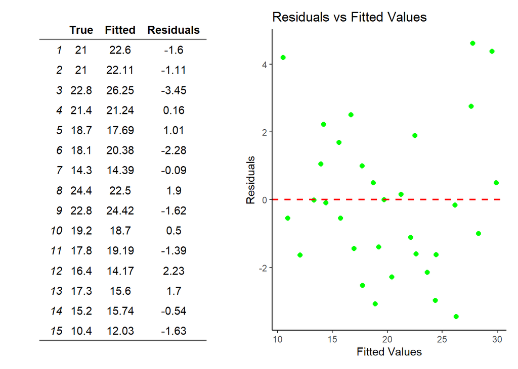

#### Multiple ($R^2$)

The multiple ($R^2$) is a statistical measure that explains how much of the variability in the dependent variable $y$ can be explained by the independent variables in the model. The formula for $R^2$ is:

$$R^2 = \left[1 - \frac{\text{SSE}}{\text{SST}}\right] = \frac{\text{SST}
- \text{SSE}}{\text{SST}} = \left[\frac{\text{SSR}}{\text{SST}}\right]$$

where:

- **SSE**: Sum of Squared Errors (Residuals), $\sum (y_i - \hat{y}_i)^2$, representing the unexplained variability.
- **SSR**: Sum of Squares for Regression, $\sum (\hat{y}_i - \bar{y})^2$, representing the variability explained by the model.
- **SST**: Total Sum of Squares, $\sum (y_i - \bar{y})^2$, representing the total variability in the response variable $y$.

**Interpretation**:

- $R^2$ ranges from 0 to 1.
- An $R^2$ value of 1 indicates that the regression model perfectly explains the variability in the dependent variable.
- An $R^2$ value close to 0 suggests that the model fails to explain the variability in the data.

For the `mtcars` dataset, the $R^2$ value is calculated as: 0.87.

#### Adjusted $R^2$

Adjusted $R^2$ is a modified version of $R^2$ that accounts for the number of predictors in the model. It adjusts for the model complexity by considering the degrees of freedom, making it a better indicator of the model’s performance, especially when adding more variables.

The formula for Adjusted $R^2$ is:

$$\text{Adjusted } R^2 = 1 - \frac{\text{SSE}/(n - p - 1)}{\text{SST}/(n -
1)}$$

where:

- **$n$**: Total number of observations.
- **$p$**: Number of independent variables (predictors) in the model.

**Adjusted $R^2$** takes into account the number of predictors and only increases if the new variable improves the model more than would be expected by chance. It can decrease if the new variable does not improve the model. It is particularly useful in multiple regression because it helps to prevent overfitting by penalizing the addition of less meaningful predictors.

*If Adjusted $R^2$ is significantly lower than $R^2$, it indicates that some of the predictors may not be adding real value to the model*

For the `mtcars` dataset, the Adjusted $R^2$ value is calculated as: 0.81.

## Recap

In this document, we conducted a thorough analysis of **Multiple Linear Regression (MLR)** using the `mtcars` dataset. Below are the key topics that were covered:

1. **Introduction to Multiple Linear Regression**:
   - MLR is an extension of Simple Linear Regression, enabling the use of multiple predictors to model the relationship between a dependent variable $y$ and multiple independent variables $x_1, x_2, ..., x_p$.
   - The `mtcars` dataset, containing various car characteristics, was used to predict `mpg` (miles per gallon).
2. **Mathematical Model**:
   - We explored the mathematical formulation of MLR:
     $$y = \beta_0 + \beta_1 x_1 + \beta_2 x_2 + ... + \beta_p x_p + \epsilon$$
   - Here, $\beta_0$ is the intercept, $\beta_1, \beta_2, ..., \beta_p$ are the coefficients, and $\epsilon$ is the error term.
3. **Correlation Matrix**:
   - A correlation matrix was used to identify relationships between variables and detect potential multicollinearity, which can affect model stability.
4. **Coefficient Estimation**:
   - We discussed the **Ordinary Least Squares (OLS)** method, which minimizes the sum of squared residuals to estimate coefficients. The coefficients were interpreted to understand the relationship between predictors and the dependent variable.
5. **Hypothesis Testing**:
   - **Global F-Test** was used to assess the overall model significance:
     - Null Hypothesis ($H_0$): All coefficients are zero.
     - Alternative Hypothesis ($H_a$): At least one coefficient is non-zero.
   - **t-Test for Individual Coefficients** determined if each predictor significantly affects `mpg`.
6. **ANOVA Table**:
   - The complete ANOVA table provided key components including Source, Sum of Squares (SS), Degrees of Freedom (df), Mean Square (MS), F-Statistic, Critical Value, and p-value. These metrics were used to assess the overall fit and significance of the model.
7. **Residual Analysis**:
   - Residuals, the differences between observed and predicted values, were analyzed to check for patterns, non-linearity, or heteroscedasticity.
   - A **Residual vs Fitted plot** was generated to visually inspect the performance of the model.
8. **$R^2$ and Adjusted $R^2$**:
   - **$R^2$**: Measures the proportion of variability in the dependent variable explained by the predictors.
     $$R^2 = \frac{\text{SSR}}{\text{SST}} = 1 - \frac{\text{SSE}}{\text{SST}}$$
   - **Adjusted $R^2$**: Adjusts for the number of predictors, making it a more reliable indicator by penalizing the addition of less meaningful variables.
     $$\text{Adjusted } R^2 = 1 - \frac{\text{SSE}/(n - p - 1)}{\text{SST}/(n -
     1)}$$
   - We calculated $R^2$ and Adjusted $R^2$ for the `mtcars` dataset, explaining their significance.
9. **Prediction Procedure**:
   - We used the regression model to predict `mpg` for new input data, illustrating the process of making predictions from the fitted MLR model.
10. **Model Evaluation**:
    - By examining various diagnostic tools such as $R^2$, Adjusted $R^2$, ANOVA, and residual analysis, we ensured the model was reliable and validated its assumptions.

## Q&A Section

1. **What is the purpose of Multiple Linear Regression?**
   - MLR models the relationship between a dependent variable and multiple independent variables, allowing for predictions and understanding of complex associations.
2. **How is the coefficient estimation done in MLR?**
   - The coefficients are estimated using the **Ordinary Least Squares (OLS)** method, which minimizes the sum of squared differences between observed and predicted values.
3. **What does the correlation matrix help identify in MLR?**
   - It helps detect relationships between variables and identify multicollinearity, which can lead to unreliable coefficient estimates.
4. **How do you interpret the coefficients in an MLR model?**
   - Each coefficient represents the expected change in the dependent variable $y$ for a one-unit increase in the corresponding predictor, holding all other predictors constant.
5. **What does a significant F-statistic indicate in the context of MLR?**
   - A significant F-statistic suggests that at least one predictor variable significantly explains the variability in the dependent variable.
6. **Why is Adjusted $R^2$ considered better than $R^2$ for multiple regression models?**
   - Adjusted $R^2$ accounts for the number of predictors and penalizes the addition of less meaningful variables, preventing overfitting.
7. **What is residual analysis, and why is it important?**
   - Residual analysis checks the differences between observed and predicted values. It helps in validating the assumptions of linear regression and detecting patterns or inconsistencies.
8. **How do you use an MLR model to make predictions for new data?**
   - Substitute the values of the independent variables into the regression equation to get the predicted value of the dependent variable.
9. **What is the role of the ANOVA table in MLR?**
   - The ANOVA table decomposes the total variability into components explained by the model (SSR) and unexplained variability (SSE). It helps assess the model’s overall significance.
10. **What happens if the Adjusted $R^2$ value is significantly lower than $R^2$?**
    - It suggests that the model may be overfitted, and some predictors might not add real value. Removing insignificant variables could improve model performance.